# hw5_ilz2105

Lulu Zhang

11/2/2019

**Problem 1**

```r
library(tidyverse)
library(rvest)
library(readr)
library(broom)

set.seed(10)
```

For numeric variables, you should fill in missing values with the mean of non-missing values For character variables, you should fill in missing values with “virginica”

```r
iris_with_missing = iris %>%
  map_df(~replace(.x, sample(1:150, 20), NA)) %>%
  mutate(Species = as.character(Species)) %>%
  janitor::clean_names()

clean_data = function(x) {
  if (is.numeric(x)){
    replace(x, is.na(x), round(mean(x, na.rm = TRUE), digits = 1))
  }
  else if(!is.numeric(x)){replace(x, is.na(x), "virginica")}
}


final_iris = map_df(iris_with_missing, ~clean_data(.x))
final_iris
```

```
## # A tibble: 150 x 5
##    sepal_length sepal_width petal_length petal_width species
##           <dbl>       <dbl>        <dbl>       <dbl> <chr>
##  1          5.1         3.5          1.4         0.2 setosa
##  2          4.9         3            1.4         0.2 setosa
##  3          4.7         3.2          1.3         0.2 setosa
##  4          4.6         3.1          1.5         1.2 setosa
##  5          5           3.6          1.4         0.2 setosa
##  6          5.4         3.9          1.7         0.4 setosa
##  7          5.8         3.4          1.4         0.3 setosa
##  8          5           3.4          1.5         0.2 setosa
##  9          4.4         2.9          1.4         0.2 setosa
## 10          4.9         3.1          3.8         0.1 setosa
## # ... with 140 more rows
```

The `final_iris` df shows the iris dataset when the NA values for the numeric variables are filled in with the mean of the non-missing values and the character variables are filled in with "virginica`.

**Problem 2**

For this problem I made a dataframe with all the file names from the `data` folder in the `_MACOSX` folder, then I iterated over file names and read in data for each subject using purrr::map and saved the result as a new variable in the dataframe. Then I tidied the result; manipulated file names to include control arm and subject ID, make sure weekly observations are “tidy”, and do any other tidying that’s necessary.

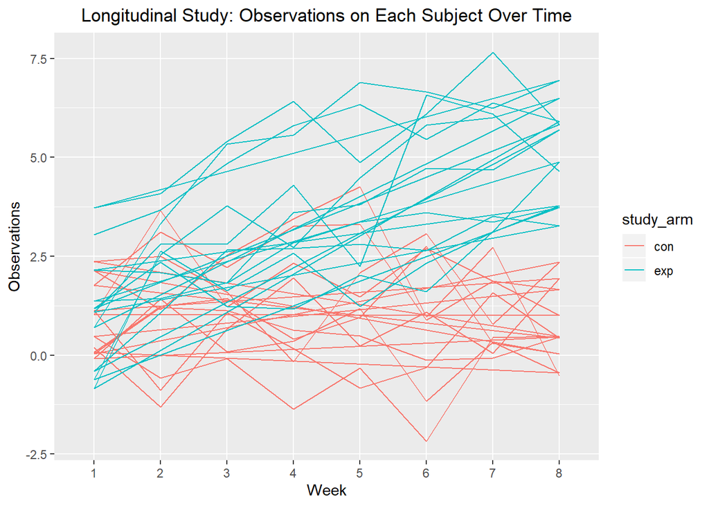

```r
files = tibble(
  names = list.files(path = "./data/", all.files = TRUE, no.. = TRUE),
  paths = str_c("./data/", names))

func = function(x){
  read_csv(x)
}
study = files %>%
  mutate(source = map(files$paths, func)) %>%
  unnest(cols = c(source)) %>%
  janitor::clean_names() %>%
  select(-paths) %>%
  separate(names, into = c("study_arm","subject_id", "type")) %>%
  select(-type) %>%
   pivot_longer(
     cols = starts_with("week_"),
    names_to = "week",
    names_prefix = "week_",
    values_to = "value") %>%
  group_by(subject_id)
# spaghetti plot

plot = study %>%
  ggplot(aes(x = week, y = value, color = study_arm, group = study_arm))+
  geom_path()+
  labs( title = "Longitudinal Study: Observations on Each Subject Over Time",
        x = "Week",
        y = "Observations")+
  theme(plot.title = element_text(hjust = 0.5))
plot
```

The spaghetti plot shows the observations on each subject over time. The experiment arm has higher observation values compared to the control arm, on average. Week 6 shows the lowest observation values for the control arm with a value of almost -2.5, and week 7 has the peak observation value for the exp arm which was about 7.6.

**Problem 3**

First set the following design elements:

Fix n=30 Fix xi1 as draws from a standard Normal distribution Fix β0=2 Fix σ2=50 Set β1=0. Generate 10000 datasets from the model yi=β0+β1xi1+ϵi

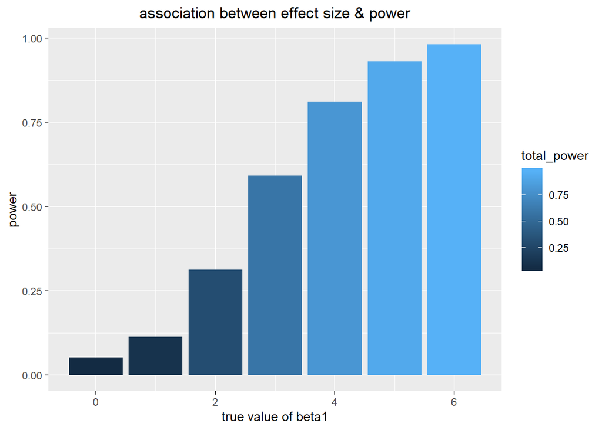

```r
generate_reg = function(n = 30, beta0 = 2, beta1, var = 50) {

  p3_data = tibble(
  x = rnorm(n, mean = 0, sd = 1),
  y = beta0 + beta1 * x + rnorm(n, 0, var^0.5)
)

  ls_fit = lm(y ~ x, data = p3_data)

  tidy(ls_fit)
}

results =
  rerun(10000, generate_reg(n = 30, var = 50, beta1 = 0)) %>%
  bind_rows() %>%
  select(term, estimate, p.value) %>%
  filter(term == "x")


power = tibble(
  beta_1 = c(0, 1, 2, 3, 4, 5, 6)) %>%
  mutate(
    output = map(.x = beta_1, ~rerun(10000, generate_reg(beta1 = .x))),
    est = map(output, bind_rows)) %>%
  select(-output) %>%
  unnest(est) %>%
  select(beta_1, term, estimate, p.value) %>%
  filter(term == "x")

final = power %>%
  group_by(beta_1) %>%
  summarize(sum_p = sum(p.value < 0.05),
            total_power = sum_p/n()) %>%
  ggplot(aes(x = beta_1, y = total_power, fill = total_power))+
  geom_bar(stat = "identity")+
  labs(title = "association between effect size & power",
       x = "true value of beta1",
       y = "power") +
  theme(plot.title = element_text(hjust = 0.5))

final
```

The plot above shows the positive association between power and the effect size. As the power increases (as the proportion of times the null was rejected increases), the true value of beta1 or the effect size increases.

Next I made a second plot showing the average estimate of β^1 only in samples for which the null was rejected on the y axis and the true value of β1 on the x axis.

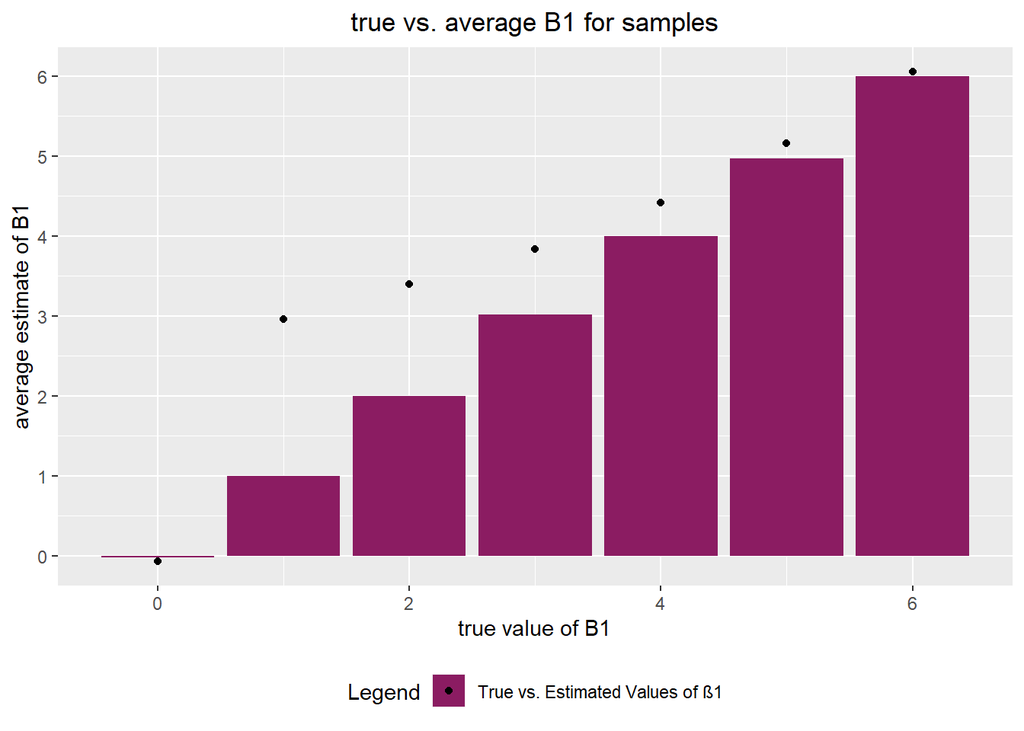

```r
final_restricted =
  power %>%
  group_by(beta_1) %>%
  summarize(
    b1_avg_est = mean(estimate),
    b1_signif = mean(estimate[p.value < 0.05], na.rm = TRUE)) %>%
  ggplot(aes(x = beta_1, y = b1_avg_est ,fill = "maroon4"))+
  geom_bar(stat = "identity")+
  geom_point(aes(x = beta_1, y = b1_signif))+
  labs( title = "true vs. average B1 for samples",
        x = "true value of B1",
        y = "average estimate of B1")+
  theme( plot.title = element_text(hjust = 0.5),
    legend.position = "bottom") +
  scale_y_continuous(breaks = seq(-1, 8, 1)) +
  scale_fill_identity(name = 'Legend', guide = 'legend',
                      labels = c('True vs. Estimated Values of β1')) +
  theme(plot.title = element_text(hjust = 0.5))

final_restricted
```